# Project 1: Wrangling, Exploration, Visualization

#### Joining/Merging

```r
# your joining code
library(tidyverse)
full <- full_join(heart, stanford, by = c("id"))
full <- full %>% select(-start) %>% select(-stop) %>% select(-age.x) %>%
    select(-year)
full$event <- ifelse(full$event == 0, "yes", "no")
full$status <- ifelse(full$status == 1, "alive", "dead")
full$surgery <- ifelse(full$surgery == 0, "noprior", "prior")
full$transplant <- ifelse(full$transplant == 0, "Y", "N")
full <- full %>% rename(age = age.y)
full %>% filter("id" == "id")
```

```
##    event surgery transplant id time status age   t5
## 1     no noprior          Y  1   15  alive  54 1.11
## 2     no noprior          Y  2    3  alive  40 1.66
## 3    yes noprior          Y  3   46  alive  42 0.61
## 4     no noprior          N  3   46  alive  42 0.61
## 5    yes noprior          Y  4  623  alive  51 1.32
## 6     no noprior          N  4  623  alive  51 1.32
## 7     no noprior          Y  5  126  alive  48 0.36
## 8     no noprior          Y  6   64  alive  54 1.89
## 9    yes noprior          Y  7 1350  alive  54 0.87
## 10    no noprior          N  7 1350  alive  54 0.87
## 11    no noprior          Y  8   23  alive  56 2.05
## 12    no noprior          Y  9  279  alive  49 1.12
##  [ reached 'max' / getOption("max.print") -- omitted 241 rows ]
```

```r
full <- full[!duplicated(full$id), ]
# your joining code
anti_join(heart, stanford, by = "id")
```

```
## [1] start      stop       event      age        year       surgery    transplant
## [8] id
## <0 rows> (or 0-length row.names)
```

```r
uniqueID <- anti_join(stanford, heart, by = "id")
semi_join(stanford, heart, by = "id")
```

```
##    id time status age   t5
## 74 74 2006      0  15 1.26
## 99 99 1232      1  18 0.70
## 43 43  227      1  19 1.02
## 66 66 1634      1  23 1.78
## 46 46  631      1  26 1.46
## 65 65 2313      0  26 0.46
## 88 88   22      1  27 1.64
## 84 84 1778      0  27 0.70
## 90 90    7      1  28 1.00
## 68 68   48      1  28 0.77
## 48 48   12      1  29 0.61
## 73 73 2025      0  30 1.44
## 96 96 1271      1  32 1.05
## 39 39 2723      1  32 1.93
## 38 38 2984      0  32 0.19
## 14 14 1961      1  33 1.06
## 83 83   68      1  35 0.85
## 69 69 2127      1  35 0.67
## 27 27   44      1  36 0.00
## 30 30 1478      1  36 1.35
##  [ reached 'max' / getOption("max.print") -- omitted 83 rows ]
```

```r
show(uniqueID)
```

```
##      id time status age   t5
## 139 139   86      1  12 1.26
## 159 159   10      1  13 1.49
## 181 181   60      0  13   NA
## 119 119 1116      0  14 0.54
## 120 120 1107      0  18 0.25
## 108 108   42      1  19 0.63
## 179 179   98      0  19   NA
## 134 134  793      0  19 1.98
## 160 160    5      1  20   NA
## 177 177  119      0  20   NA
## 153 153  534      0  20   NA
## 136 136  781      0  20 1.12
## 133 133    1      1  21 0.47
## 176 176  149      0  21   NA
## 157 157  468      0  24 1.39
## 114 114 1193      0  24 1.15
## 184 184    1      0  27   NA
## 182 182   56      0  27   NA
## 180 180   89      0  27   NA
## 163 163  391      0  27 1.17
##  [ reached 'max' / getOption("max.print") -- omitted 61 rows ]
```

The original heart data set has 172 observations with 8 variables while stanford had 184 observations. I used full join because most of the data were similar however, there were specific data that were interesting to me so I thought it would be better to keep all the rows. I decided to join by “id” because the stanford data just added more patients from the heart data. These data are similar but had different variables.There were many duplicates of the ID column so I deleted these. The final data set ended up with 184 observations. I decided to change the columns a bit because some of the data were repetitive after joining. I deleted start, stop, year and age.x because time and age.y already stated these numbers without any math. There are a couple of patient ids that did not make it in the full join and there were 81 observations. As a result, there are 81 unique values of ID in the stanford dataset and 0 unique values of ID in the heart dataset. The unique values are shown in the uniqueID dataset. There are 103 common observations between the two datasets.  
The full join data set has 184 observations for 8 variables. No variables were dropped during the joining, this means all data was retained, this means that the 81 unique values of stanford are part of the full dataset. If observations were dropped, it could have been a problem because sample size would decreases and important data could be lost. However, later in the project NA was omitted because it affected the data, after omitting the NAs there were 98 observations meaning 86 observations were lost. #### Wrangling

```r
# your wrangling code
full %>% filter(transplant == "Y")
```

```
##    event surgery transplant id time status age   t5
## 1     no noprior          Y  1   15  alive  54 1.11
## 2     no noprior          Y  2    3  alive  40 1.66
## 3    yes noprior          Y  3   46  alive  42 0.61
## 4    yes noprior          Y  4  623  alive  51 1.32
## 5     no noprior          Y  5  126  alive  48 0.36
## 6     no noprior          Y  6   64  alive  54 1.89
## 7    yes noprior          Y  7 1350  alive  54 0.87
## 8     no noprior          Y  8   23  alive  56 2.05
## 9     no noprior          Y  9  279  alive  49 1.12
## 10   yes noprior          Y 10 1024  alive  43 1.13
## 11   yes noprior          Y 11   10  alive  56 2.76
## 12    no noprior          Y 12   39  alive  42 1.38
##  [ reached 'max' / getOption("max.print") -- omitted 91 rows ]
```

```r
full %>% arrange(desc(time))
```

```
##    event surgery transplant id time status age   t5
## 1     no noprior          Y 19 3695   dead  40 0.38
## 2    yes noprior          Y 26 3410   dead  45 0.98
## 3    yes noprior          Y 36 3021   dead  38 0.98
## 4    yes noprior          Y 38 2984   dead  32 0.19
## 5    yes noprior          Y 25 2878  alive  49 0.75
## 6     no   prior          Y 44 2805   dead  48 1.20
## 7    yes noprior          Y 47 2734   dead  47 0.97
## 8    yes noprior          Y 39 2723  alive  32 1.93
## 9    yes   prior          Y 50 2474  alive  52 1.70
## 10   yes noprior          Y 65 2313   dead  26 0.46
## 11   yes noprior          Y 69 2127  alive  35 0.67
## 12   yes noprior          Y 71 2106   dead  40 0.86
##  [ reached 'max' / getOption("max.print") -- omitted 172 rows ]
```

```r
full %>% group_by(status) %>% mutate(meant5 = mean(t5))
```

```
## # A tibble: 184 x 9
## # Groups:   status [2]
##    event surgery transplant    id  time status   age    t5 meant5
##    <chr> <chr>   <chr>      <dbl> <dbl> <chr>  <dbl> <dbl>  <dbl>
##  1 no    noprior Y              1    15 alive     54  1.11     NA
##  2 no    noprior Y              2     3 alive     40  1.66     NA
##  3 yes   noprior Y              3    46 alive     42  0.61     NA
##  4 yes   noprior Y              4   623 alive     51  1.32     NA
##  5 no    noprior Y              5   126 alive     48  0.36     NA
##  6 no    noprior Y              6    64 alive     54  1.89     NA
##  7 yes   noprior Y              7  1350 alive     54  0.87     NA
##  8 no    noprior Y              8    23 alive     56  2.05     NA
##  9 no    noprior Y              9   279 alive     49  1.12     NA
## 10 yes   noprior Y             10  1024 alive     43  1.13     NA
## # … with 174 more rows
```

```r
full %>% select(transplant, t5)
```

```
##    transplant   t5
## 1           Y 1.11
## 2           Y 1.66
## 3           Y 0.61
## 5           Y 1.32
## 7           Y 0.36
## 8           Y 1.89
## 9           Y 0.87
## 11          Y 2.05
## 12          Y 1.12
## 13          Y 1.13
## 15          Y 2.76
## 17          Y 1.38
## 18          Y 0.96
## 20          Y 1.06
```

[output cut: 37 more lines]

```r
full %>% filter(transplant == "Y") %>% summarize(mean(t5))
```

```
##   mean(t5)
## 1       NA
```

```r
full <- full %>% na.omit()
# your wrangling code

table1 <- full %>% summarize(meantime = mean(time), sdtime = sd(time),
    maxtime = max(time), meanage = mean(age), sdage = sd(age),
    medianage = (median(age)), mediant5 = median(t5), maxt5 = max(t5),
    meant5 = mean(t5), mint5 = min(t5))


full %>% group_by(surgery) %>% summarize(median(time))
```

```
## # A tibble: 2 x 2
##   surgery `median(time)`
##   <chr>            <dbl>
## 1 noprior            544
## 2 prior              547
```

```r
full %>% group_by(status) %>% summarize(mean(t5))
```

```
## # A tibble: 2 x 2
##   status `mean(t5)`
##   <chr>       <dbl>
## 1 alive       1.20
## 2 dead        0.971
```

```r
str_detect(full, "no")
```

```
## [1]  TRUE  TRUE FALSE FALSE FALSE FALSE FALSE FALSE
```

```r
colSums(is.na(full))
```

```
##      event    surgery transplant         id       time     status        age
##          0          0          0          0          0          0          0
##         t5
##          0
```

```r
# your wrangling code
table2 <- full %>% group_by(event, surgery) %>% summarize(Avgtime = mean(time),
    Avgage = mean(age), avgt5 = mean(t5), sdtime = sd(time),
    sdage = sd(age), sdt5 = sd(t5))

timehour <- function(x) {
    x/60
}
full %>% summarize(timehour(time))
```

```
##    timehour(time)
## 1     0.250000000
## 2     0.050000000
## 3     0.766666667
## 4    10.383333333
## 5     2.100000000
## 6     1.066666667
## 7    22.500000000
## 8     0.383333333
## 9     4.650000000
## 10   17.066666667
## 11    0.166666667
## 12    0.650000000
## 13   12.166666667
## 14   32.683333333
```

[output cut: 84 more lines]

```r
library(kableExtra)
full %>% group_by(event, surgery, status) %>% summarize(n())
```

```
## # A tibble: 8 x 4
## # Groups:   event, surgery [4]
##   event surgery status `n()`
##   <chr> <chr>   <chr>  <int>
## 1 no    noprior alive     21
## 2 no    noprior dead       6
## 3 no    prior   alive      2
## 4 no    prior   dead       1
## 5 yes   noprior alive     42
## 6 yes   noprior dead      14
## 7 yes   prior   alive     10
## 8 yes   prior   dead       2
```

```r
tablef1 <- table1 %>% kable(digits = 3, align = "l", col.names = str_to_title(names(.)))
show(table1)
```

```
##   meantime   sdtime maxtime  meanage    sdage medianage mediant5 maxt5   meant5
## 1 924.9439 978.5888    3695 43.90816 9.690134        46     1.07  3.05 1.142755
##   mint5
## 1     0
```

```r
tablef2 <- table2 %>% kable(digits = 3, align = "llccccc", col.names = str_to_title(names(.)))
show(table2)
```

```
## # A tibble: 4 x 8
## # Groups:   event [2]
##   event surgery Avgtime Avgage avgt5 sdtime sdage  sdt5
##   <chr> <chr>     <dbl>  <dbl> <dbl>  <dbl> <dbl> <dbl>
## 1 no    noprior    719.   44.3  1.27   926.  9.41 0.657
## 2 no    prior     1056    39.7  1.28  1515. 18.0  0.308
## 3 yes   noprior   1037.   43.8  1.03  1003.  9.70 0.559
## 4 yes   prior      831.   44.8  1.35   889.  9.10 0.651
```

#### Visualizing

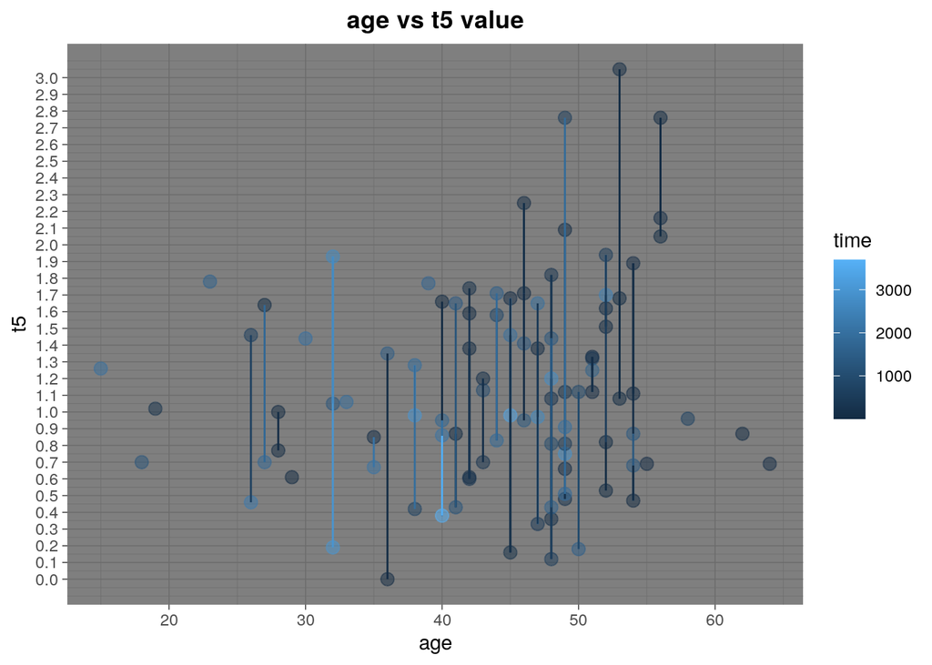

```r
# your plot 1
ggplot(full, aes(x = age, y = t5, color = time)) + geom_point(size = 3,
    alpha = 0.5) + geom_line(aes(group = age)) + theme_dark() +
    scale_y_continuous(breaks = seq(0, 3, 0.1)) + ggtitle("age vs t5 value") +
    theme(plot.title = element_text(face = "bold", hjust = 0.5))
```

Your discussion of plot 1 This plot is testing if there was a relationship between age and t5. This plot plots the age versus the t5 value. This plot also groups by age meaning seeing if by grouping by age it affects t5 and this plot is colored by time which shows how much time the heart transplant took of each point. This plot shows no relationship between age and t5. The plot also shows that time is not affected by age or t5, all of these values are all over the place indicating no relationship. However, there does seem to be a small relationship between age and t5 but, these seem like outliers because the t5 values seem to be in the same general area.

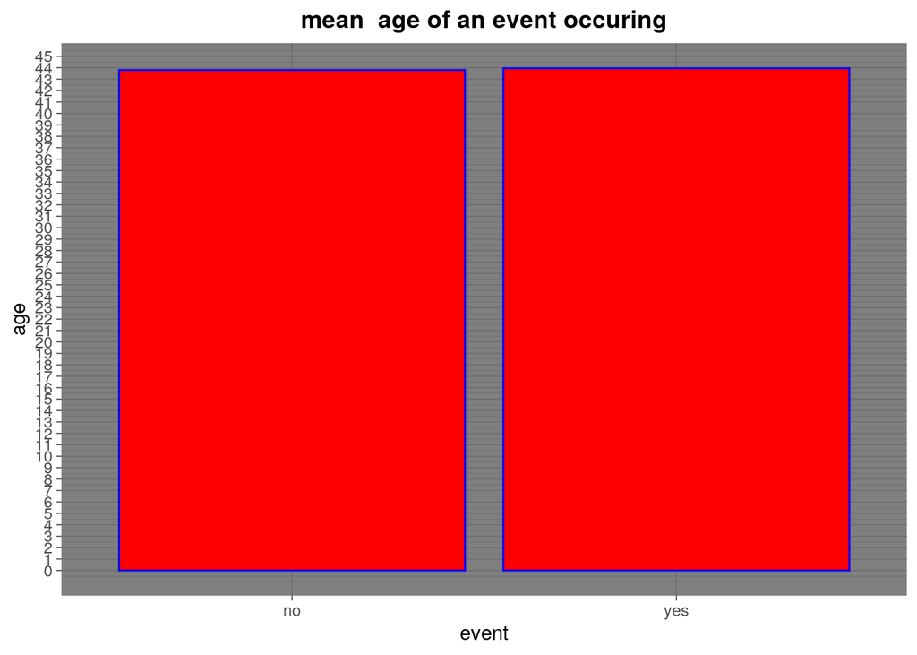

```r
# your plot 2
ggplot(full, aes(x = event)) + geom_bar(aes(y = age), stat = "summary",
    fun = mean, color = "blue", fill = "red") + scale_y_continuous(breaks = seq(0,
    45, 1)) + ggtitle("mean  age of an event occuring") + theme_dark() +
    theme(plot.title = element_text(hjust = 0.5, face = "bold"))
```

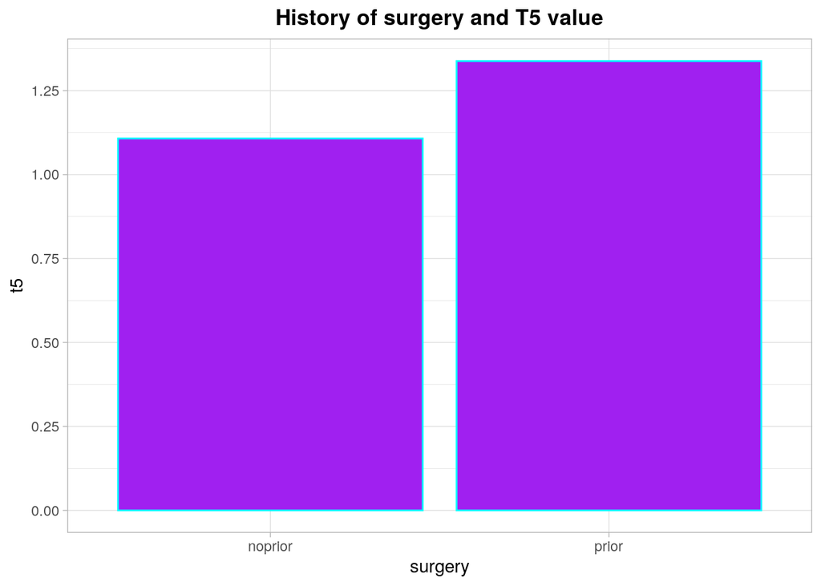

```r
# your plot 3
ggplot(full, aes(x = surgery)) + geom_bar(aes(y = t5), stat = "summary",
    fun = mean, color = "cyan", fill = "purple") + scale_y_continuous(breaks = seq(0,
    2, 0.25)) + ggtitle("History of surgery and T5 value") +
    theme_light() + theme(plot.title = element_text(hjust = 0.5,
    face = "bold"))
```

Your discussion of plot 3 This bar plot focuses on whether or not a patient had previous surgery or not. This graph shows that the mean t5 value of whether or not a patient had previous surgery. A patient who has had no prior surgery had a lower t5 value than a prior surgery.

#### Concluding Remarks

This project was a lot of work but it was really fun to see what we learned. I know python is next and am excited to see what is next! If any!